# Democracy and The Rule of Law

Hoi-Ying Mak 4/26/2018

- Introduction
- 1.Relationship between the rule of law and democracy
- 2.Different Legacies from Britain and France
- 3.Variations Among Former British Colonies
- 4.Democratization in Asia and Africa (Part I)
- 5.Democratization in Asia and Africa (Part II)
- 6.Asia: The Dissolved British and French Territories

## Introduction

Democracy and the rule of law are often regarded as closely associated universal values. They are also viewed as wonderful legacies that the Western powers have left to their former colonies. Is this really the case? This report revisits the conventional wisdom by looking at the data from 10 Asian and African countries which gained independence from Britain or France after World War II (WWII).

This report uses two sets of data:

1. [Unified Democracy Scores (UDS)](http://www.unified-democracy-scores.org/uds.html), which incorporates data from 1946 to 2012 from three original measures - Freedom House (2014), Polity IV (Marshall et al. 2012) and VanHanen (2012).
2. [World Bank’s Rule of Law Index](http://databank.worldbank.org/data/reports.aspx?source=worldwide-governance-indicators#), a subset of its governance indicators, measures and ranks the public’s trust in a country’s rule of law from 1996 to 2016.

In this report, I select a sample of 10 countries , including five former British colonies (Malaysia, Singapore, Zambia, Ghana, Sierra Leone), and five former French colonies (Cambodia, Laos, Morocco, Algeria, Tunisia). Each group is composed of two Asian countries and three African countries.

```r
#Import the UDS democracy index
democracy <- read_csv("uds_summary.csv") %>%
#Filter the 10 countries for my analysis
    filter(country %in% c("Malaysia",
                      "Singapore",
                      "Zambia",
                      "Ghana",
                      "Sierra Leone",
                      "Laos",
                      "Cambodia",
                      "Morocco",
                      "Algeria",
                      "Tunisia")) %>%
#Remove useless variables
   select(country, year, mean) %>%
#Rename variables to match with the law dataframe
   rename(Year = "year",
          Country = "country",
          Demo_Score = "mean")


#Import the WB's Rule of Law Index
#The data was narrowed down to the 10 countries when downloaded from WB
law <- read_csv("Rule_of_law_WB.csv") %>%
#Rename variables
    rename(ROL_Estimate = "Rule of Law: Estimate [RL.EST]",
           ROL_Percentile = "Rule of Law: Percentile Rank [RL.PER.RNK]",
           Year = "Time",
           Country = "Country Name") %>%
#Select the estimate scores and ranking (percentile) of rule of law
    select(Year,
           Country,
           ROL_Estimate,
           ROL_Percentile) %>%
#Change Lao PDR to Laos to match the democracy data
    mutate(Country = ifelse(Country == "Lao PDR", 'Laos', Country)) %>%
#Change Year to numeric
    mutate(Year = as.numeric(Year))


#Combine the two dataframes
demo_law <- democracy %>%
    left_join(law, by = c("Year", "Country"))
```

## 1.Relationship between the rule of law and democracy

The following line graph shows the general bivariate relationship between the levels of democracy and the estimate scores of the rule of law. It covers years 1996 to 2012 as this is the time frame the two datasets have in common.

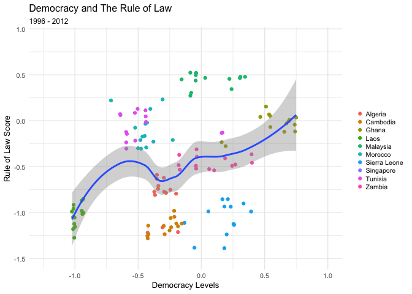

```r
demo_law %>%
#Show bivariate relationship between law and democracy scores
  ggplot(aes(Demo_Score,
        ROL_Estimate), na.rm = TRUE) +
#Use color to indicate variations among countries
  geom_point(aes(color = Country)) +
  geom_smooth() +

#Adjust the scale of x-axis and y-axis
  scale_y_continuous(limits = c(-1.5, 0.9))+
  scale_x_continuous(limits = c(-1.25, 1))+
  theme_minimal(base_size = 10)+
#Adjust size and title of the legend
  theme(legend.key.size = unit(0.35, "cm"),
        legend.title = element_blank())+
  labs(x = "Democracy Levels",
       y = "Rule of Law Score",
       title = "Democracy and The Rule of Law",
       subtitle = "1996 - 2012")
```

The loess line shows a crude positive relationship between the level of democracy and the estimated score of the rule of law.

What are the determinants behind these variations among the 10 countries? The following graphs explore potential influence from different colonial powers (Britain VS France) and regions (Asia VS Africa).

## 2.Different Legacies from Britain and France

The following graph compare the law and democracy scores of two group of countries - former British colonies, and former French colonies.

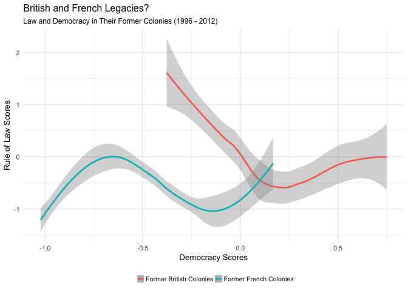

```r
#Create a data set for former British colonies
British <- demo_law %>%
  filter(Country %in% c("Malaysia",
                        "Singapore",
                         "Ghana",
                        "Zambia",
                        "Sierra Leone"))

#Create a data set for former French colonies
French <- demo_law %>%
  filter(Country %in% c ("Cambodia",
                         "Laos",
                         "Algeria",
                         "Morocco",
                         "Tunisia"))

#Plot a line for each group to make comparison
ggplot() +
  geom_smooth(data = British,
              mapping = aes(Demo_Score, ROL_Estimate,
              color = "Former British Colonies")) +
  geom_smooth(data = French,
              mapping = aes(Demo_Score, ROL_Estimate,
              color = "Former French Colonies"))+
    theme_minimal(base_size = 10) +

#Format the legend to fit the size and shape of the graph
    theme(legend.key.size = unit(0.3, "cm"),
        legend.title = element_blank(),
        legend.position = "bottom",
        legend.direction = "horizontal") +
 labs(x = "Democracy Scores",
      y = "Rule of Law Scores",
      title = "British and French Legacies?",
      subtitle = "Law and Democracy in Their Former Colonies (1996 - 2012)")
```

The comparison shows former British colonies generally have a significantly higher level of democracy, and moderately better rule of law (the red line is located on the right, upper hand side).

## 3.Variations Among Former British Colonies

The following graph compares the world rankings (in percentile) of the rule of law of the five British colonies.

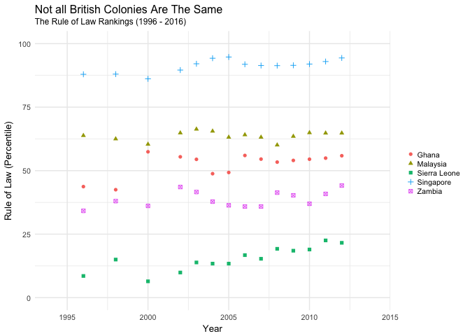

```r
#Recycle the former British colonies dataset
British %>%
#Use percentile to compare thier world rankings
  ggplot(aes(x = Year,
             y = ROL_Percentile,
             shape = Country,
             color = Country)) +
  geom_point() +
#Format the scale of y-axis and x-axis to match data
   scale_y_continuous(limits = c(0, 100)) +
   scale_x_continuous(limits = c(1994, 2014)) +
  theme_minimal(base_size = 10) +
  theme(legend.key.size = unit(0.35, "cm"),
        legend.title = element_blank()) +
   labs(x = "Year",
      y = "Rule of Law (Percentile)",
      title = "Not all British Colonies Are The Same",
      subtitle = "The Rule of Law Rankings (1996 - 2016)")
```

The above graph demonstrates huge variations between different British colonies. On the higher end, Singapore (in blue), which has a renowoned legal system, has consistently ranked at the world top (> 80th percentile) in its performance of the rule of law. On the contrary, the African country Sierra Leone has never made its way out of the lower quartile (25th percentile) in its quality of the rule of law after 1996.

Therefore, while the British legacy may have to a certain extent shaped the political institutions in these countries in the post-colonial era, the endogenous political and cultural tradition of each of these countries has obviously played an imperative role as well.

## 4.Democratization in Asia and Africa (Part I)

The following graph compares the change of levels of democracy in Asian and African former colonies from 1946 to 2012.

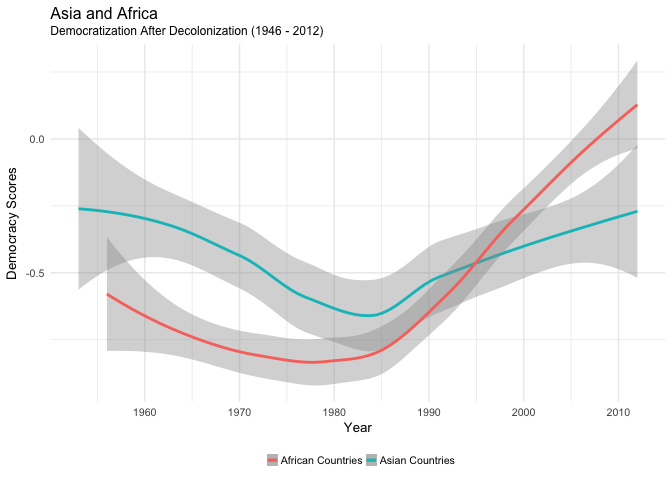

```r
#Create a dataset for Asian countries
Asia <- demo_law %>%
  filter(Country %in% c("Malaysia",
                      "Singapore",
                        "Cambodia",
                        "Laos"))
#Create a dataset for African countries
Africa <- demo_law %>%
  filter(Country %in% c ("Ghana",
                        "Zambia",
                        "Sierra Leone",
                         "Algeria",
                         "Morocco",
                         "Tunisia"))

ggplot() +
#Make two line graphs to compare democracy in Asia and Africa
  geom_smooth(data = Asia,
              mapping = aes(Year, Demo_Score,
              color = "Asian Countries")) +
  geom_smooth(data = Africa,
              mapping = aes(Year, Demo_Score,
              color = "African Countries"))+
    theme_minimal(base_size = 10) +
#Format the legend to fit size of graph
    theme(legend.key.size = unit(0.3, "cm"),
        legend.title = element_blank(),
        legend.position = "bottom",
        legend.direction = "horizontal") +
 labs(x = "Year",
      y = "Democracy Scores",
      title = "Asia and Africa",
      subtitle = "Democratization After Decolonization (1946 - 2012)")
```

The above graph shows the African countries, which initially lagged behind the Asian countries before 1990, have surpassed the latter by embarking a huge progress in democratization in the past two decades.

Nevertheless, both groups of countries have demonstrated similarly low scores of democracy (mostly < 0). It can be explained with the lack-of-democracy nature of colonial rule, which has profound impact on shaping the post-colonial institutions in these countries.

## 5.Democratization in Asia and Africa (Part II)

The following graph details the range of democracy scores of each of the 10 countries during 1946 to 2012.

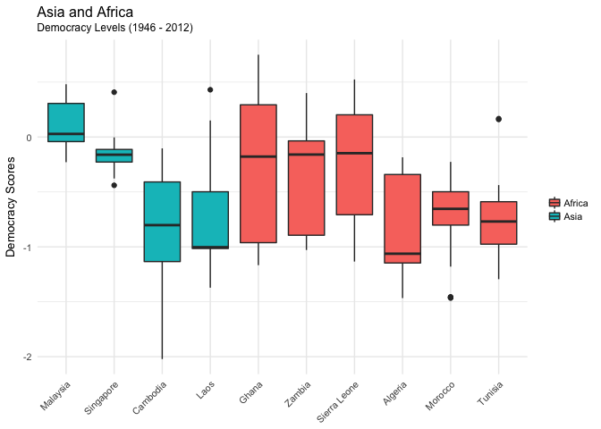

```r
demo_law %>%
#Create a new variable to differentiate Asian/African countries
  mutate(AA = ifelse(
    Country %in% c(
      "Malaysia","Singapore",
      "Cambodia","Laos"),
    "Asia", "Africa")) %>%

#Use factor to reorder countries for Asian/African grouping
  mutate(Country = factor(
    Country, levels = c(
      "Malaysia", "Singapore",
          "Cambodia", "Laos",
           "Ghana", "Zambia",
           "Sierra Leone", "Algeria",
           "Morocco", "Tunisia"))) %>%

#Use fill to visualize African/Asian groupings by color
  ggplot(mapping = aes(
    x = Country,
    y = Demo_Score,
    fill = AA)) +
  geom_boxplot() +
  theme_minimal(base_size = 10) +
#Format to adjust the legend and x-axis lebels
    theme(legend.key.size = unit(0.4, "cm"),
        legend.title = element_blank(),
         axis.text.x =
            element_text(angle=45, hjust=1)) +
 labs(x = NULL,
      y = "Democracy Scores",
      title = "Asia and Africa",
      subtitle = "Democracy Levels (1946 - 2012)")
```

## 6.Asia: The Dissolved British and French Territories

The following graphs compares democracy of two interesting pairs: 1) Malyaisa and Singapore, which were separated from the dissolved British Malaya; 2) Laos and Cambodia, which were separated from the dissolved French Indochina.

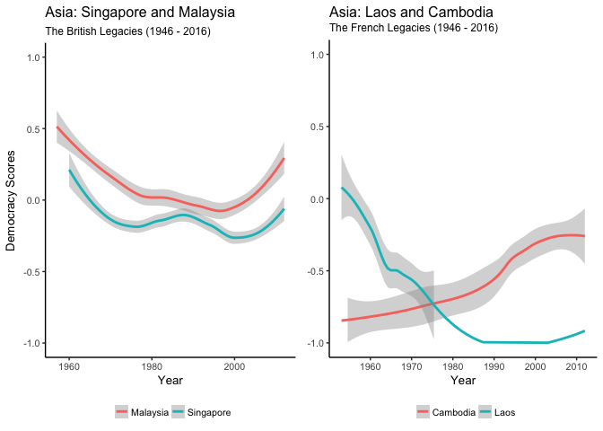

```r
#Create the fist data set for former British colonies in Asia
Br_Asia <- demo_law %>%
  filter(Country %in% c("Malaysia", "Singapore")) %>%
#Draw line graph to show democracy trend
  ggplot(aes(x = Year,
             y = Demo_Score,
             color = Country)) +
  geom_smooth()+
  theme_classic(base_size = 10) +
#Adjust the scale to match the second graph
  scale_y_continuous(limits = c(-1, 1))+
  theme(legend.key.size = unit(0.4, "cm"),
        legend.title = element_blank(),
#Move the legend to bottom to fit graphs
        legend.position = "bottom")+
  labs(x = "Year",
       y = "Democracy Scores",
       title = "Asia: Singapore and Malaysia",
       subtitle = "The British Legacies (1946 - 2016)")

#Create the second data set for former French colonies in Asia
Fr_Asia <- demo_law %>%
  filter(Country %in% c("Laos", "Cambodia")) %>%
#Draw line graph to show democracy trend
  ggplot(aes(x = Year,
               y = Demo_Score,
               color = Country)) +
  geom_smooth( ) +
    theme_classic(base_size = 10) +
#Adjust the scale to match the first graph
    scale_y_continuous(limits = c(-1, 1)) +
  theme(legend.key.size = unit(0.4, "cm"),
        legend.title = element_blank(),
#Move the legend to bottom to fit graphs
        legend.position = "bottom") +
  labs(x = "Year",
       y = NULL,
       title = "Asia: Laos and Cambodia",
       subtitle = "The French Legacies (1946 - 2016)")

#Use ggarrange from ggpubr to juxtapose the two graphs
#Compare French and British legacies in Asia
ggarrange(Br_Asia, Fr_Asia,
          ncol = 2)
```

The above graphs show the former British-ruled twins - Malaysia and Singapore, has generally better scores in levels of democracy. Their performance are rather stable. On the other hand, the former French-ruled twins - Cambodia and Laos, shows a more robust democracy score change throughout the past six decades. Cambodia, in particular, has made remarkable progress in improving its democracy, moving from almost -1.0, to > -0.5 in the latest data.